# Dataset McCard_2021

This dataset is from McCard et al. (2021): https://doi.org/10.1007/s10530-021-02487-7

- Contains n=287 feeding trials.
- Raw data is available.
- Single-prey experiments ran for 3 hours, multi-prey for 1 hour.
- Eaten prey were not replaced during single-prey experiments, but replaced in multi-prey.
- We fitted a mix of ODE-based predictions and direct FR predictions, accordingly.
- Holling-3 was identified as the best fitting model. Other models performed equally.
- The model predicts switching from avoidance to preference of prey 1.
- Single-prey data was systematically over-predicted, while multi-prey data was systematically under-predicted. This is likely because of strong diffences in experimental duration.

## Setup

```r
rm(list=ls())
library("rstan")
library("loo")
library("coda")
library("deSolve")
library("BayesianTools")
library("readxl")
```

Load MSFR functions that can be used with the `deSolve` package, used for posterior predictions later.

```r
source("desolve_models.R")
```

Compile Stan models. Can be skipped if already executed before, models are saved in `.Rdata` files.

```r
source("compilation_loo_mixed.R")
```

Load compiled Stan models.

```r
load("stan_model_H2_mixed.RData")
load("stan_model_H3_mixed.RData")
load("stan_model_Yo_mixed.RData")
load("stan_model_New_mixed.RData")
```

## Prepare data

`df.all` includes all observations, `df.multi` only multi-species experiments, `df.single.1` and `df.single.2` only single-species experiments, respectively.

```r
df.single = read_excel("10530_2021_2487_MOESM1_ESM.xlsx", sheet=1)
df.switch  = read_excel("10530_2021_2487_MOESM1_ESM.xlsx", sheet=2)
head(df.single)
```

```
# A tibble: 6 × 4
  density eaten alive spp
    <dbl> <dbl> <dbl> <chr>
1       2     2     0 A. salina
2       2     2     0 A. salina
3       2     2     0 A. salina
4       2     2     0 A. salina
5       2     2     0 A. salina
6       2     2     0 A. salina
```

```r
head(df.switch)
```

```
# A tibble: 6 × 4
  prey       supply eaten  pair
  <chr>       <dbl> <dbl> <dbl>
1 P. varians     45    39     1
2 P. varians     45    42     2
3 P. varians     45    41     3
4 P. varians     45    40     4
5 P. varians     45    41     5
6 P. varians     45    39     6
```

```r
df.sub.1 = subset(df.single, spp=="P. varians")
df.single.1 = cbind( df.sub.1$density,
                     rep(0, nrow(df.sub.1)),
                     df.sub.1$eaten,
                     rep(0, nrow(df.sub.1)) ) |> unname() |> as.data.frame()
colnames(df.single.1) = c("Prey1", "Prey2", "Prey1.Eaten", "Prey2.Eaten")

df.sub.2 = subset(df.single, spp=="G. oceanicus")
df.single.2 = cbind( rep(0, nrow(df.sub.2)),
                     df.sub.2$density,
                     rep(0, nrow(df.sub.2)),
                     df.sub.2$eaten) |> unname() |> as.data.frame()
colnames(df.single.2) = c("Prey1", "Prey2", "Prey1.Eaten", "Prey2.Eaten")

n.multi = max(df.switch$pair)
df.multi = data.frame(Prey1=rep(NA, n.multi),
                      Prey2=rep(NA, n.multi),
                      Prey1.Eaten=rep(NA, n.multi),
                      Prey2.Eaten=rep(NA, n.multi))

for(i in 1:n.multi){
  ID1 = which(df.switch$prey=="P. varians" & df.switch$pair==i)
  ID2 = which(df.switch$prey=="G. oceanicus" & df.switch$pair==i)
  df.multi[i, ] = c(df.switch$supply[ID1],
                    df.switch$supply[ID2],
                    df.switch$eaten[ID1],
                    df.switch$eaten[ID2])
}
```

Single-species experiments were performed without prey replacement for 3 hours, while multi-species experiments were performed with prey replacement for 1 hour.

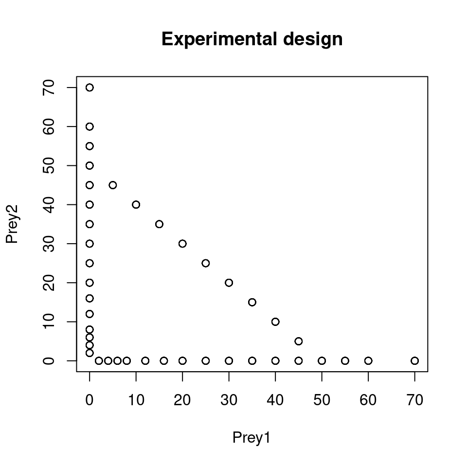

```r
df.single.1$Time = 3.0
df.single.2$Time = 3.0
df.multi$Time = 1.0
df.single.1$Replaced = 0
df.single.2$Replaced = 0
df.multi$Replaced = 1

df.all = rbind(df.multi, df.single.1, df.single.2)

plot(df.all[, c(1,2)], main="Experimental design")
```

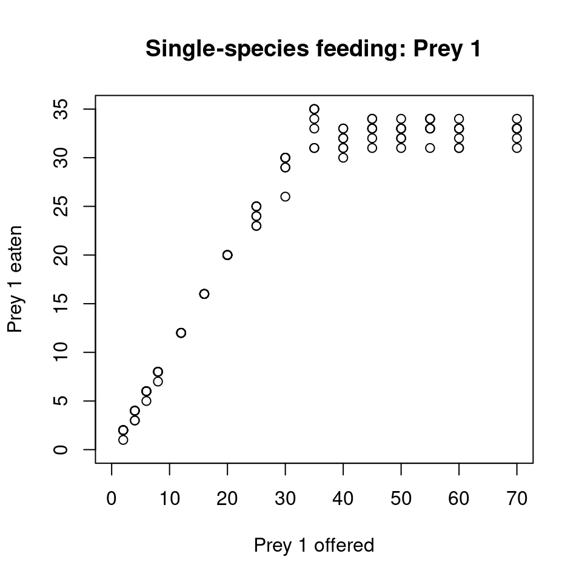

```r
plot(df.single.1$Prey1, df.single.1$Prey1.Eaten, xlim=c(0,70), ylim=c(0,35),
     xlab="Prey 1 offered", ylab="Prey 1 eaten",
     main="Single-species feeding: Prey 1")
```

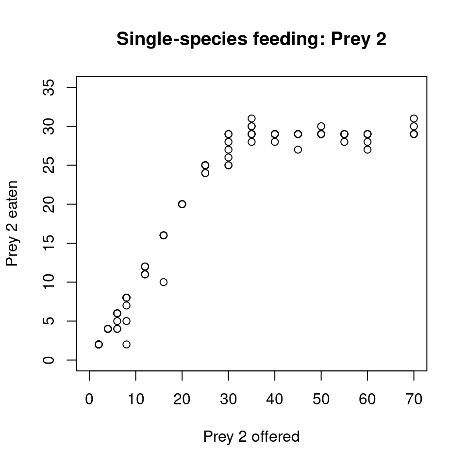

```r
plot(df.single.2$Prey2, df.single.2$Prey2.Eaten, xlim=c(0,70), ylim=c(0,35),
     xlab="Prey 2 offered", ylab="Prey 2 eaten",
     main="Single-species feeding: Prey 2")
```

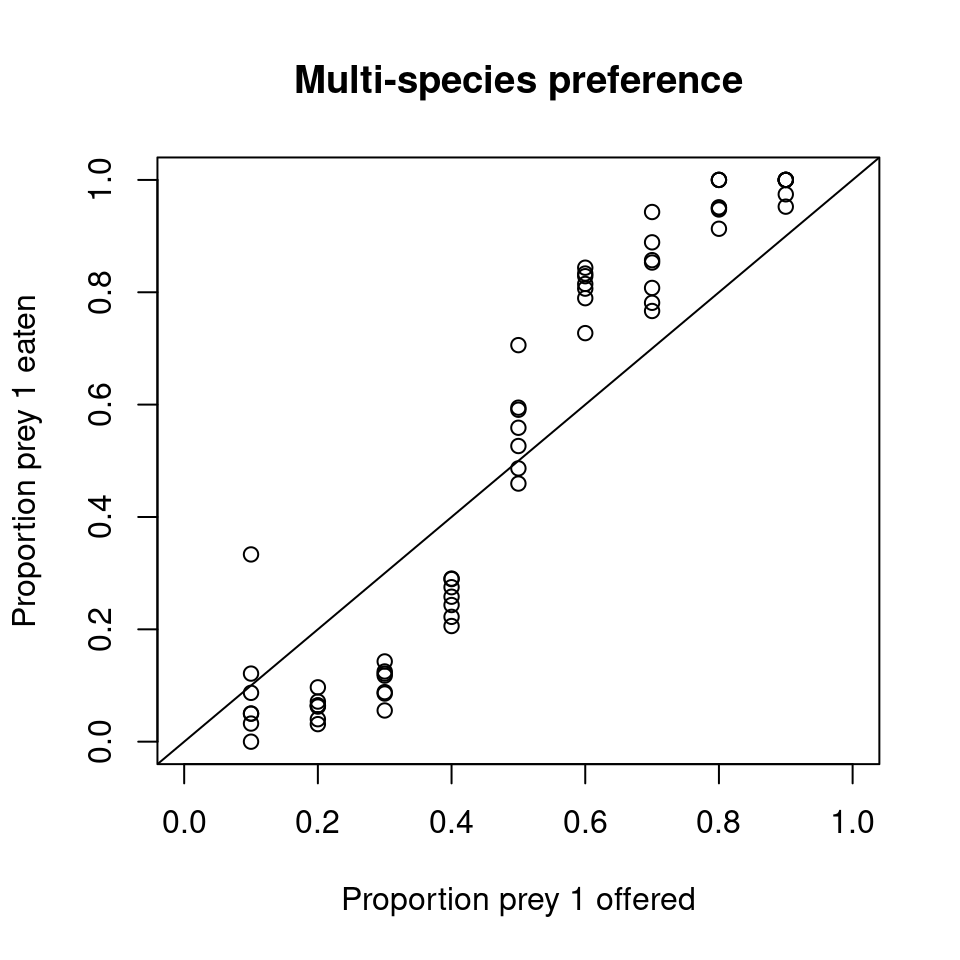

```r
plot(df.multi$Prey1/(df.multi$Prey1+df.multi$Prey2),
     df.multi$Prey1.Eaten/(df.multi$Prey1.Eaten+df.multi$Prey2.Eaten),
     xlim=c(0,1), ylim=c(0,1),
     xlab="Proportion prey 1 offered", ylab="Proportion prey 1 eaten",
     main="Multi-species preference")
abline(0,1)
```

```r
data.stan = list(n = nrow(df.all),
                 m = 2,
                 N_0 = df.all[, 1:2],
                 N_e = df.all[, 3:4],
                 Time = df.all$Time,
                 Replaced = df.all$Replaced
)
```

## Model fitting

For all models, posterior distributions are sampled using 3 chains, 1000 warmup steps and 2000 sampling steps, each. Initial values `init` are provided for all parameters. Convergence of MCMC is verified through `Rhat` value close to 1 and sufficient number of effective samples `n_eff`.

```r
chains = 3
```

### Fit Holling 2

```r
init = rep(list(list(a = c(1.0,1.0),
                     h = c(1/10,1/10))
),chains)

fit1 = sampling(
  model.H2,
  data = data.stan,
  chains = chains,
  warmup = 1000,
  iter = 3000,
  cores = 3,
  init = init,
  refresh = 100
)
```

```r
print(fit1, pars=c("a","h"))
```

```
Inference for Stan model: anon_model.
3 chains, each with iter=3000; warmup=1000; thin=1;
post-warmup draws per chain=2000, total post-warmup draws=6000.

     mean se_mean   sd 2.5%  25%  50%  75% 97.5% n_eff Rhat
a[1] 1.30       0 0.09 1.13 1.23 1.29 1.36  1.48  1483    1
a[2] 1.07       0 0.07 0.94 1.02 1.07 1.12  1.22  1542    1
h[1] 0.05       0 0.00 0.04 0.04 0.05 0.05  0.05  1562    1
h[2] 0.05       0 0.00 0.05 0.05 0.05 0.05  0.06  1621    1

Samples were drawn using NUTS(diag_e) at Mon Nov  6 11:28:39 2023.
For each parameter, n_eff is a crude measure of effective sample size,
and Rhat is the potential scale reduction factor on split chains (at
convergence, Rhat=1).
```

### Fit Holling 3

```r
init = rep(list(list(a = c(0.1,0.1),
                     h = c(1/10,1/10),
                     q = 1)
),chains)

fit2 = sampling(
  model.H3,
  data = data.stan,
  chains = chains,
  warmup = 1000,
  iter = 3000,
  cores = 3,
  init = init,
  refresh = 100
)
```

```r
print(fit2, pars=c("a","h","q"))
```

```
Inference for Stan model: anon_model.
3 chains, each with iter=3000; warmup=1000; thin=1;
post-warmup draws per chain=2000, total post-warmup draws=6000.

     mean se_mean   sd 2.5%  25%  50%  75% 97.5% n_eff Rhat
a[1] 1.12       0 0.12 0.90 1.04 1.12 1.20  1.37  2248    1
a[2] 0.90       0 0.10 0.73 0.84 0.90 0.97  1.10  2192    1
h[1] 0.07       0 0.00 0.06 0.07 0.07 0.07  0.07   838    1
h[2] 0.08       0 0.00 0.07 0.08 0.08 0.08  0.08   830    1
q    0.51       0 0.10 0.32 0.45 0.51 0.57  0.69  1141    1

Samples were drawn using NUTS(diag_e) at Mon Nov  6 12:01:43 2023.
For each parameter, n_eff is a crude measure of effective sample size,
and Rhat is the potential scale reduction factor on split chains (at
convergence, Rhat=1).
```

### Fit Yodzis FR

```r
init = rep(list(list(a = c(1,1),
                     h = c(1/10,1/10),
                     w = c(0.5,0.5),
                     r = 1)
),chains)

fit3 = sampling(
  model.Yo,
  data = data.stan,
  chains = chains,
  warmup = 1000,
  iter = 3000,
  cores = 3,
  init = init,
  refresh = 100
)
```

```r
print(fit3, pars=c("a","h","w","r"))
```

```
Inference for Stan model: anon_model.
3 chains, each with iter=3000; warmup=1000; thin=1;
post-warmup draws per chain=2000, total post-warmup draws=6000.

     mean se_mean   sd 2.5%  25%  50%  75% 97.5% n_eff Rhat
a[1] 2.11       0 0.17 1.80 2.00 2.11 2.22  2.46  3159    1
a[2] 1.59       0 0.11 1.39 1.52 1.59 1.66  1.82  2823    1
h[1] 0.06       0 0.00 0.06 0.06 0.06 0.06  0.06  3230    1
h[2] 0.06       0 0.00 0.06 0.06 0.06 0.07  0.07  2954    1
w[1] 0.49       0 0.03 0.43 0.47 0.49 0.51  0.55  2875    1
w[2] 0.51       0 0.03 0.45 0.49 0.51 0.53  0.57  2875    1
r    1.26       0 0.09 1.09 1.19 1.25 1.31  1.44  4406    1

Samples were drawn using NUTS(diag_e) at Mon Nov  6 12:29:35 2023.
For each parameter, n_eff is a crude measure of effective sample size,
and Rhat is the potential scale reduction factor on split chains (at
convergence, Rhat=1).
```

### Fit New FR

```r
init = rep(list(list(a = c(1,1),
                     h = c(1/10,1/10),
                     w = c(0.5,0.5),
                     q = 0.1,
                     r = 0.1)
),chains)

fit4 = sampling(
  model.New,
  data = data.stan,
  chains = chains,
  warmup = 1000,
  iter = 3000,
  cores = 3,
  init = init,
  refresh = 100
)
```

```r
print(fit4, pars=c("a","h","w","q","r"))
```

```
Inference for Stan model: anon_model.
3 chains, each with iter=3000; warmup=1000; thin=1;
post-warmup draws per chain=2000, total post-warmup draws=6000.

     mean se_mean   sd 2.5%  25%  50%  75% 97.5% n_eff Rhat
a[1] 1.76       0 0.25 1.32 1.59 1.74 1.92  2.29  3143    1
a[2] 1.23       0 0.15 0.94 1.12 1.22 1.33  1.54  3396    1
h[1] 0.07       0 0.00 0.07 0.07 0.07 0.07  0.08  2918    1
h[2] 0.08       0 0.00 0.08 0.08 0.08 0.08  0.09  2988    1
w[1] 0.47       0 0.05 0.38 0.44 0.47 0.50  0.56  2942    1
w[2] 0.53       0 0.05 0.44 0.50 0.53 0.56  0.62  2942    1
q    0.43       0 0.08 0.27 0.37 0.42 0.48  0.61  2511    1
r    0.74       0 0.13 0.48 0.66 0.75 0.83  1.00  2517    1

Samples were drawn using NUTS(diag_e) at Mon Nov  6 13:19:54 2023.
For each parameter, n_eff is a crude measure of effective sample size,
and Rhat is the potential scale reduction factor on split chains (at
convergence, Rhat=1).
```

## Model comparison

Extract log-likelihood values for all fits and compute predictive performance with leave-one-out cross validation using the `loo` package.

```r
lik1 = extract_log_lik(fit1, merge_chains=FALSE)
reff1 = relative_eff(exp(lik1), cores=4)
loo1 = loo(lik1, r_eff=reff1, cores=4)

lik2 = extract_log_lik(fit2, merge_chains=FALSE)
reff2 = relative_eff(exp(lik2), cores=4)
loo2 = loo(lik2, r_eff=reff2, cores=4)

lik3 = extract_log_lik(fit3, merge_chains=FALSE)
reff3 = relative_eff(exp(lik3), cores=4)
loo3 = loo(lik3, r_eff=reff3, cores=4)

lik4 = extract_log_lik(fit4, merge_chains=FALSE)
reff4 = relative_eff(exp(lik4), cores=4)
loo4 = loo(lik4, r_eff=reff4, cores=4)

loo_compare(loo1, loo2, loo3, loo4)
```

```
       elpd_diff se_diff
model2   0.0       0.0
model1  -8.9      25.1
model4 -12.5      15.4
model3 -35.4      22.2
```

Holling-3 has the highest `elpd` score, but including uncertainty (`se_diff`) it is equivalent to Holling-2. Since we observe a clear switching pattern in the multi-species data, we identify Holling-3 as the best fitting model.

Its posterior distributions of all parameters and their multivariate correlation are plotted.

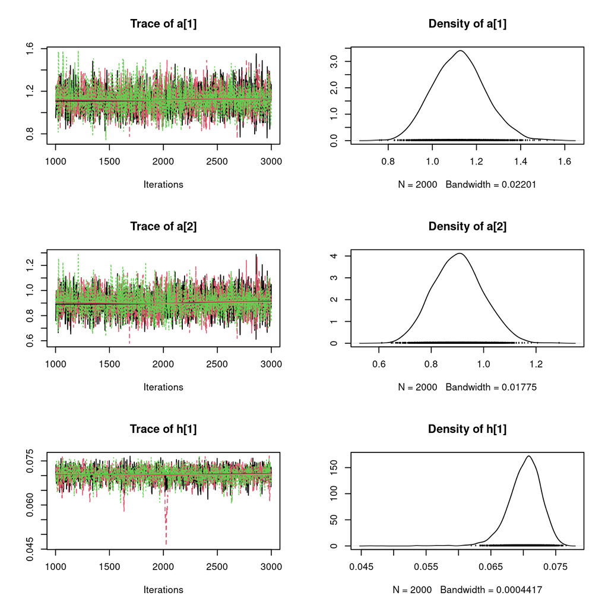

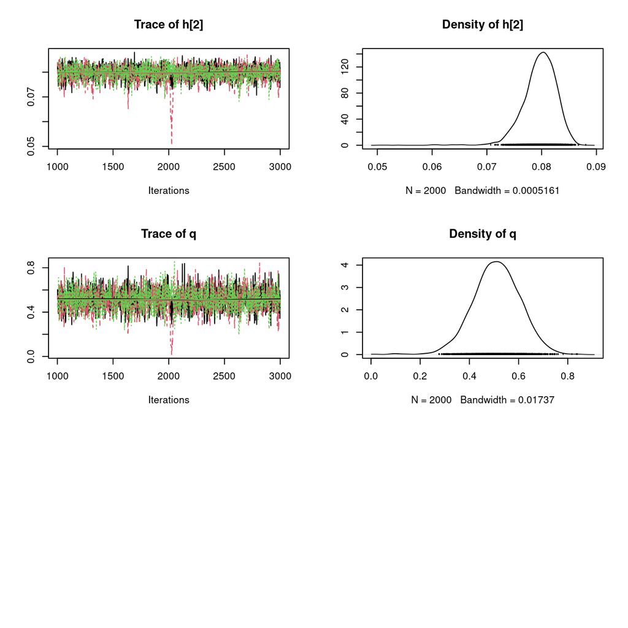

```r
plot(As.mcmc.list(fit2)[, 1:5])
```

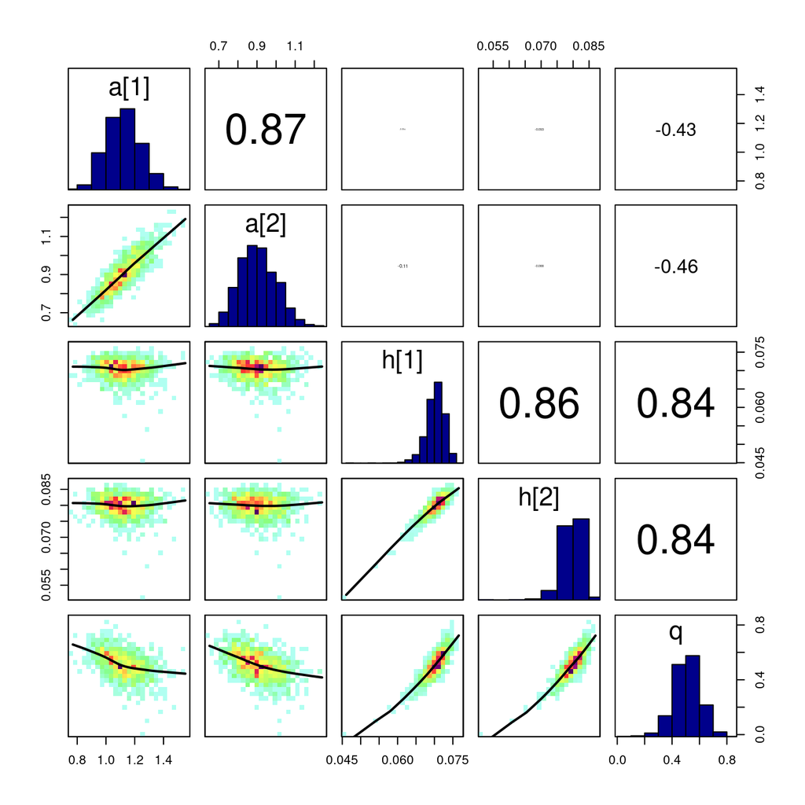

```r
correlationPlot(as.matrix(fit2)[, 1:5])
```

## Posterior predictions for best fitting model

The correct `MSFR` model function is chosen for `deSolve`. 1000 samples from the posterior distribution are chosen randomly. For these, predictions are generated through numerical simulation of ODEs. Their median and 90% credible intervals are plotted against observed data.

```r
MSFR = Holling3

n.post = 1000
n.pred = 20
post = as.matrix(fit2)[, 1:5]
set.seed(100)
post = post[sample(1:nrow(post),n.post), ]
```

### Single-species prey 1

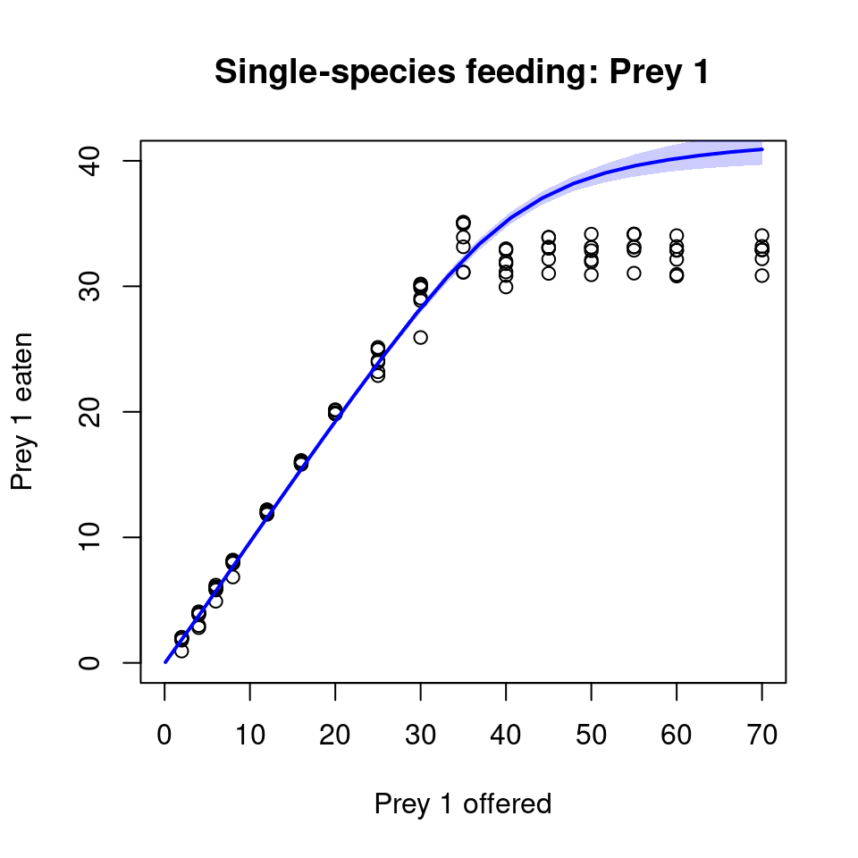

```r
N10.pred = seq(0.1, 70, length.out=n.pred)
N1E.pred = matrix(NA, nrow=n.post, ncol=n.pred)

for(k in 1:n.post){
  params = list(a=post[k, 1:2],
                h=post[k, 3:4],
                q=post[k, 5],
                m=2)
  for(i in 1:n.pred){
    out = ode(y = c(N=c(N10.pred[i], 0.0)), times = c(0,3), func = MSFR, parms = params)
    N1E.pred[k,i] = N10.pred[i]-out[2,2]
  }
}

N1E.pred.qs = apply(N1E.pred, 2, function(x) quantile(x, probs=c(0.05, 0.5, 0.95)))

plot(df.single.1$Prey1, jitter(df.single.1$Prey1.Eaten, factor=1), xlim=c(0,70), ylim=c(0,40),
     xlab="Prey 1 offered", ylab="Prey 1 eaten",
     main="Single-species feeding: Prey 1")
polygon( c(N10.pred, rev(N10.pred)),
         c(N1E.pred.qs[1, ], rev(N1E.pred.qs[3, ])),
         border=NA,
         col=adjustcolor("blue", alpha.f=0.2)
)
lines(N10.pred, N1E.pred.qs[2, ], col="blue", lwd=2)
```

### Single-species prey 2

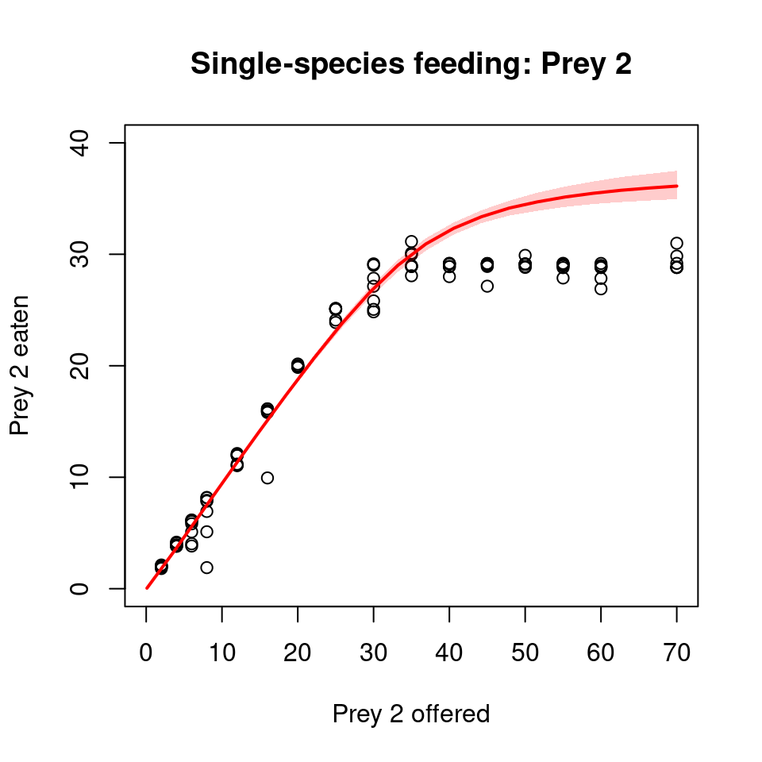

```r
N20.pred = seq(0.1, 70, length.out=n.pred)
N2E.pred = matrix(NA, nrow=n.post, ncol=n.pred)

for(k in 1:n.post){
  params = list(a=post[k, 1:2],
                h=post[k, 3:4],
                q=post[k, 5],
                m=2)
  for(i in 1:n.pred){
    out = ode(y = c(N=c(0.0, N20.pred[i])), times = c(0,3), func = MSFR, parms = params)
    N2E.pred[k,i] = N20.pred[i]-out[2,3]
  }
}

N2E.pred.qs = apply(N2E.pred, 2, function(x) quantile(x, probs=c(0.05, 0.5, 0.95)))
plot(df.single.2$Prey2, jitter(df.single.2$Prey2.Eaten, factor=1), xlim=c(0,70), ylim=c(0,40),
     xlab="Prey 2 offered", ylab="Prey 2 eaten",
     main="Single-species feeding: Prey 2")

polygon( c(N20.pred, rev(N20.pred)),
         c(N2E.pred.qs[1, ], rev(N2E.pred.qs[3, ])),
         border=NA,
         col=adjustcolor("red", alpha.f=0.2)
)
lines(N20.pred, N2E.pred.qs[2, ], col="red", lwd=2)
```

### Multi-species relative consumption

Multi-species predictions are computed along a gradient of relative composition of N1 and N2 with N1+N2=50.

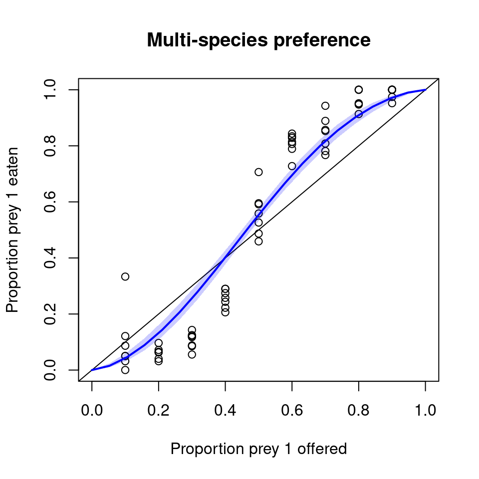

```r
N0.total = 50

N10.pred = seq(0, N0.total, length.out=n.pred)
N20.pred = N0.total-N10.pred
N1E.pred = matrix(NA, nrow=n.post, ncol=n.pred)
N2E.pred = matrix(NA, nrow=n.post, ncol=n.pred)

for(k in 1:n.post){
  params = list(a=post[k, 1:2],
                h=post[k, 3:4],
                q=post[k, 5],
                m=2)
  for(i in 1:n.pred){
    out = -(1)*unlist(MSFR(t=0, N=c(N10.pred[i], N20.pred[i]), parms=params))
    N1E.pred[k,i] = out[1]
    N2E.pred[k,i] = out[2]
  }
}

N1E.pred.qs = apply(N1E.pred, 2, function(x) quantile(x, probs=c(0.05, 0.5, 0.95)))
N2E.pred.qs = apply(N2E.pred, 2, function(x) quantile(x, probs=c(0.05, 0.5, 0.95)))

# make relative
N1E.pred.rel = matrix(NA, nrow=n.post, ncol=n.pred)
N2E.pred.rel = matrix(NA, nrow=n.post, ncol=n.pred)
for(k in 1:n.post){
  N1E.pred.rel[k, ] = N1E.pred[k, ]/(N1E.pred[k, ]+N2E.pred[k, ])
  N2E.pred.rel[k, ] = N2E.pred[k, ]/(N1E.pred[k, ]+N2E.pred[k, ])
}

N1E.pred.rel.qs = apply(N1E.pred.rel, 2, function(x) quantile(x, probs=c(0.05, 0.5, 0.95)))
N2E.pred.rel.qs = apply(N2E.pred.rel, 2, function(x) quantile(x, probs=c(0.05, 0.5, 0.95)))

plot(df.multi$Prey1/(df.multi$Prey1+df.multi$Prey2),
     jitter(df.multi$Prey1.Eaten/(df.multi$Prey1.Eaten+df.multi$Prey2.Eaten), factor=3),
     xlim=c(0,1), ylim=c(0,1),
     xlab="Proportion prey 1 offered", ylab="Proportion prey 1 eaten",
     main="Multi-species preference")
abline(0,1)
polygon( c(N10.pred/N0.total, rev(N10.pred/N0.total)),
         c(N1E.pred.rel.qs[1, ], rev(N1E.pred.rel.qs[3, ])),
         border=NA,
         col=adjustcolor("blue", alpha.f=0.2)
)
lines(N10.pred/N0.total, N1E.pred.rel.qs[2, ], col="blue", lwd=2)
```

The model predicts switching from avoidance to preference of prey 1.

### Multi-species feeding

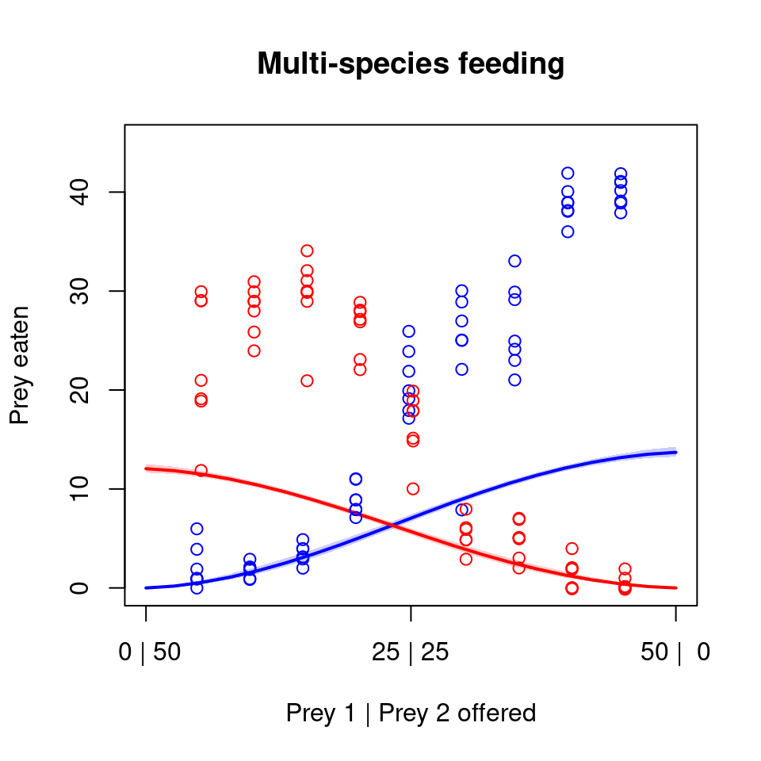

```r
plot(NA, xlim=c(0,50), ylim=c(0,45), xaxt="n", ylab="", xlab="",
     main="Multi-species feeding")
title(ylab="Prey eaten", xlab="Prey 1 | Prey 2 offered")
axis(1, at = c(0,25,50), labels = c(" 0 | 50", "25 | 25", "50 |  0"))
polygon( c(N10.pred, rev(N10.pred)),
         c(N1E.pred.qs[1, ], rev(N1E.pred.qs[3, ])),
         border=NA,
         col=adjustcolor("blue", alpha.f=0.2)
)
polygon( c(50-N20.pred, rev(50-N20.pred)),
         c(N2E.pred.qs[1, ], rev(N2E.pred.qs[3, ])),
         border=NA,
         col=adjustcolor("red", alpha.f=0.2)
)
lines(N10.pred, N1E.pred.qs[2, ], col="blue", lwd=2)
lines(50-N20.pred, N2E.pred.qs[2, ], col="red", lwd=2)
points(df.multi$Prey1-0.2,
       jitter(df.multi$Prey1.Eaten, factor=0.75),
       col="blue")
points(50-df.multi$Prey2+0.2, # reverse
       jitter(df.multi$Prey2.Eaten, factor=0.75),
       col="red")
```

### Multi-species observed vs. predicted

Additionally, median predicted numbers of eaten prey (N1E and N2E) are computed and plotted against observed data points.

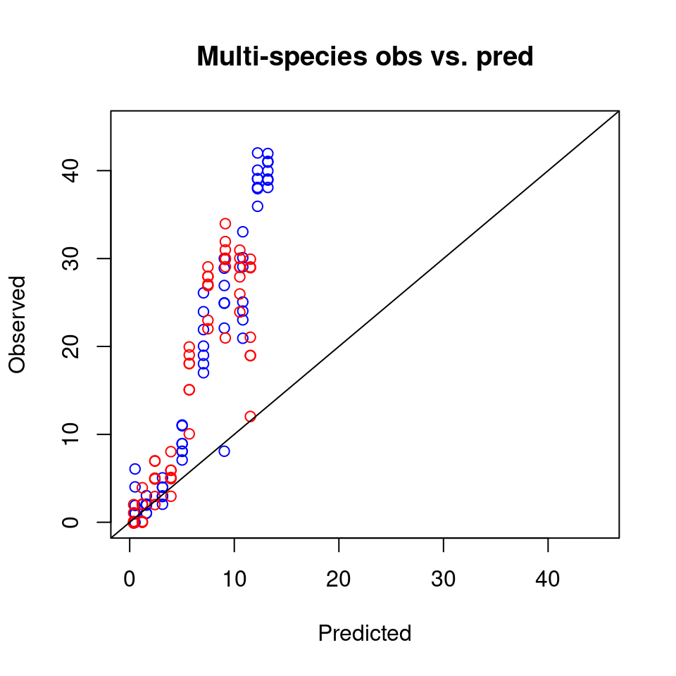

```r
N1E.pred = matrix(NA, nrow=n.post, ncol=nrow(df.multi))
N2E.pred = matrix(NA, nrow=n.post, ncol=nrow(df.multi))

for(k in 1:n.post){
  params = list(a=post[k, 1:2],
                h=post[k, 3:4],
                q=post[k, 5],
                m=2)
  for(i in 1:nrow(df.multi)){
    out = -(1)*unlist(MSFR(t=0, N=c(df.multi$Prey1[i],df.multi$Prey2[i]), parms=params))
    N1E.pred[k,i] = out[1]
    N2E.pred[k,i] = out[2]
  }
}

N1E.pred.qs = apply(N1E.pred, 2, function(x) quantile(x, probs=c(0.05, 0.5, 0.95)))
N2E.pred.qs = apply(N2E.pred, 2, function(x) quantile(x, probs=c(0.05, 0.5, 0.95)))

plot(NULL, xlim=c(0,45), ylim=c(0,45), xlab="Predicted", ylab="Observed",
     main="Multi-species obs vs. pred")
points(N1E.pred.qs[2, ], jitter(df.multi$Prey1.Eaten, factor=0.5), col="blue")
points(N2E.pred.qs[2, ], jitter(df.multi$Prey2.Eaten, factor=0.5), col="red")
abline(0,1)
```